# Yung Regression Correction

# Regression Confounding Correction Method

Here I am testing the method derived by CNYung in his master’s dissertation for correcting GWAS summary statistics.

He presents two models, 0 and 1, where they are unadjusted and adjusted for ancestry confounding, respectively. We can relate the two models.

$$\beta_{0,j} = \beta_{1,j} +
\phi_1\omega_{1,j} + ... + \phi_m\omega_{m,j}$$

Where:

$$\omega_{k,j}: =
\frac{\alpha_{k,j}}{\sqrt{\overline{\alpha_j}(1-\overline{\alpha_j})}}$$
for k = 1,…,m , where m is the number of anestry groups, and j is the SNP, and $\alpha$ is the allele frequency. Therefore, $\alpha_{k,j}$ is the reference allele frequency for ancestry k, and $\overline{\alpha_j}$ is the mean allele frequency across all ancestries, m, or the observed AF. And also that means $\omega_{k,j}$ represents the standardized allele frequency.

## Testing this method

We want to test 4 scenarios:

| AF std? | Optimize |  |
| --- | --- | --- |
| “” | Summix | Regression |
| std AF | ? | CNYung |
| raw AF | OURS | ? |

He simulated:

- ancestry group proportions
- AF
- ancestry-weighted AF means
- raw and standardized SNP data
- raw and standardized phenotypes

```r
# load in chr19 LD filtered data
chr19 <- read.csv("C:/Users/HayBa/Documents/Graduate School/Local Ancestry/chr19_v3.1.2_LD0.2.csv")

# set working directory
setwd("C:/Users/HayBa/Documents/Graduate School/PRS/")

# set seed for reproducbility
set.seed(100)

# load any packages
library(tidyverse)
library(scales)
```

For first test use just 10,000 SNPs

```r
# first make sure no 0 AFs for AFR or EUR in data
chr19 <- chr19 %>% filter(AF_AFR > 0.1 | AF_EUR > 0.1)
chr19 <- chr19 %>% filter(AF_AFR < .9 | AF_EUR < .9)
chr19_sub <- chr19[sample(1:nrow(chr19), 10000), ]
gc()
```

```
            used   (Mb) gc trigger   (Mb)  max used   (Mb)
Ncells   6125172  327.2   15161554  809.8  12165930  649.8
Vcells 162430915 1239.3  475531050 3628.1 594383573 4534.8
```

For simplicity, I’m going to start with m=2 – aka an AFR/AFRAM simulation

```r
# simulate reference AFs
NRef <- 500
NObs <- 5000

# set the ancestry group proportions
ancestryProps <- c(0.8, 0.2)

# calculate each individual's ancestry proportions
X_ancestryProps <- data.frame(prop_afr = rnorm(n = NObs, mean = ancestryProps[1], sd = .4))
X_ancestryProps[which(X_ancestryProps$prop_afr > 1), ] <- 1
X_ancestryProps[which(X_ancestryProps$prop_afr < 0), ] <- 0
X_ancestryProps <- X_ancestryProps %>% rowwise() %>%
  mutate(prop_eur = 1 - prop_afr)

# X_trans <- sqrt(NObs-1) *
#   (prcomp(as.matrix(X_ancestryProps), center = F, scale = F)$x %*%
#      diag(sort(eigen(t(as.matrix(X_ancestryProps)) %*% as.matrix(X_ancestryProps))$values^(-1/2))))
summary(X_ancestryProps)
```

```
    prop_afr         prop_eur
 Min.   :0.0000   Min.   :0.0000
 1st Qu.:0.5278   1st Qu.:0.0000
 Median :0.8035   Median :0.1965
 Mean   :0.7225   Mean   :0.2775
 3rd Qu.:1.0000   3rd Qu.:0.4722
 Max.   :1.0000   Max.   :1.0000
```

```r
# simulate reference AFs
NRef <- 500
NObs <- 5000
NAnc <- 2
NSNPs <- nrow(chr19_sub)

# ------------- old -----------------
# first AFR
# genos <- t(sapply(chr19_sub$AF_AFR, function(x) {
#     rmultinom(1, NRef, c(x^2, 2*x*(1-x), (1-x)^2))
#   }))
# AF_AFR <- apply(genos, 1, function(x) ((x[1]*2)+x[2])/(2*NRef))
# #AF_AFR[AF_AFR == 0] <- .000001
# # EUR AFs
# genos <- t(sapply(chr19_sub$AF_EUR, function(x) {
#     rmultinom(1, NRef, c(x^2, 2*x*(1-x), (1-x)^2))
#   }))
# AF_EUR <- apply(genos, 1, function(x) ((x[1]*2)+x[2])/(2*NRef))
# #AF_EUR[AF_EUR == 0] <- .000001
#
# # observed AF (weighted by ancestry props)
# AA_sim <- function(data, n, prop_afr, prop_eur) {
#     genos <- t(sapply(data$AF_AFR, function(x) {
#       rmultinom(1, n, c(x^2, 2*x*(1-x), (1-x)^2))
#     }))
#     af_sim_afr <- apply(genos, 1, function(x) ((x[1]*2)+x[2])/(2*n))
#
#     genos <- t(sapply(data$AF_EUR, function(x) {
#       rmultinom(1, n, c(x^2, 2*x*(1-x), (1-x)^2))
#     }))
#     af_sim_eur <- apply(genos, 1, function(x) ((x[1]*2)+x[2])/(2*n))
#     af_sim <- af_sim_afr*prop_afr + af_sim_eur*prop_eur
#
#     af_sim[af_sim == 0] <- .000001
#
#     return(af_sim)
# }
# AF_obs <- AA_sim(data = chr19_sub,
#                  n = NObs,
#                  prop_afr = ancestryProps[1],
#                  prop_eur = ancestryProps[2])
#
# alpha <- data.frame(alpha_afr = AF_AFR,
#                    alpha_eur = AF_EUR)
# alpha <- t(as.matrix(alpha))
# str(alpha)

# ------------ NEW ------------------
rho = 0.65 # pairwise correlation between normal random variables used in copula
# rho is the average correlation between the group AFs
# I tested AFR - EUR which was ~.65, so I'll try that
# C N Yung used .95 - which would be more like finescale

# simulate AFs for each group
alpha = t(matrix(
  pnorm(
    MASS::mvrnorm(
      n = nrow(chr19_sub),
      mu = rep(0, NAnc),
      Sigma = rho * (rep(1, NAnc) %*% t(rep(1, NAnc))) + (1 - rho) * diag(NAnc)
    )
  ),
  ncol = NAnc
))

# across-group ancestry-weighted means of those frequencies at each SNP
alpha_bar = colMeans(as.matrix(X_ancestryProps)) %*% alpha
```

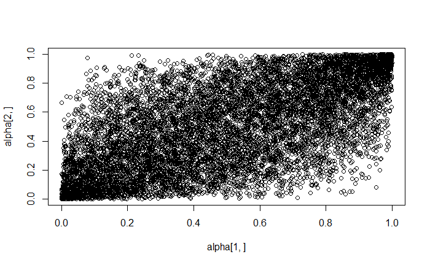

```r
#Check correlation between alphas (reference AFs)
plot(alpha[1,], alpha[2,])
```

```r
DescTools::CCC(alpha[1,], alpha[2,])$rho.c$est
```

```
[1] 0.6301556
```

```r
# simulate genotypes where each row is an individual and each column is the AC for each SNP
# uses alpha (allele frequencies)
# CURRENTLY USING ALPHA_BAR, WANT TO ALSO TEST USING SUMMIX AF_OBS I think?
genos <- matrix(0, nrow = NObs, ncol = nrow(chr19_sub))
genos_std <- genos
for(j in 1:ncol(genos)) {
  raw_geno <- rbinom(NObs, size = 2, prob = as.matrix(X_ancestryProps) %*% alpha[,j])
  if(length(unique(raw_geno) == 1)) { # ensure all individuals don't have same genotype count
    # otherwise will end up with zero variance
    if(unique(raw_geno)[1] == 1) {
      raw_geno[1] <- 0
    } else {
      raw_geno[1] <- 1
    }
  }
  genos[,j] <- raw_geno
  genos_std[,j] <- (genos[,j]-mean(genos[,j])) / sd(genos[,j])
}



# simulate phenotypes, raw and centered
gamma = 0.05 # proportion of variance of phenotype explained by ancestry

W <- rnorm(NObs, mean = 0, sd = 1)
tau <- sqrt((gamma/(1-gamma))/(sum(as.matrix(X_ancestryProps)^2)/NObs))
mu <- rnorm(NAnc, mean = 0, sd = tau)

raw_phenotype <- as.matrix(X_ancestryProps) %*% mu + W

# center the phenotypes
centered_phenotype <- scale(raw_phenotype, scale = F)
```

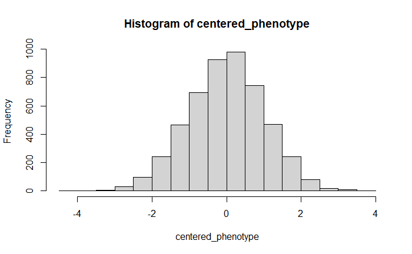

```r
# check phenotype looks OK
hist(centered_phenotype)
```

Now do the actual regressions…

As a reminder:

- X = Ancestry proportion data
- Y = phenotype
- Z = genotype (AC)

```r
results <- data.frame(coef_no_anc = rep(0, NSNPs), # beta_0j
                      coef_with_anc = rep(0, NSNPs), #beta_1j
                      z_no_anc = rep(0, NSNPs),
                      z_with_anc = rep(0, NSNPs),
                      p_no_anc = rep(0, NSNPs),
                      p_with_anc = rep(0, NSNPs))


for(j in 1:nrow(chr19_sub)) {
  alldata <- data.frame(Y = centered_phenotype,
                      X_afr = X_ancestryProps$prop_afr,
                      X_eur = X_ancestryProps$prop_eur,
                      Z = genos_std[,j])
  # first do model 0 without ancestry
  mod_no_anc <- lm(Y ~ 0 + ., data = alldata[ ,c(1, NAnc+2)])
  results[j,]$coef_no_anc <- summary(mod_no_anc)$coef[1]
  results[j,]$z_no_anc <- summary(mod_no_anc)$coef[3]
  results[j,]$p_no_anc <- summary(mod_no_anc)$coef[4]

  # now do model 1 with ancestry
  mod_with_anc <- lm(Y ~ 0 + ., data = alldata)
  results[j,]$coef_with_anc <- summary(mod_with_anc)$coef[3, 1]
  results[j,]$z_with_anc <- summary(mod_with_anc)$coef[3,3]
  results[j,]$p_with_anc <- summary(mod_with_anc)$coef[3,4]

  if(j %% 1000 == 0) {
    print(paste0("SNP ", j, " done"))
  }
}
```

```
[1] "SNP 1000 done"
[1] "SNP 2000 done"
[1] "SNP 3000 done"
[1] "SNP 4000 done"
[1] "SNP 5000 done"
[1] "SNP 6000 done"
[1] "SNP 7000 done"
[1] "SNP 8000 done"
[1] "SNP 9000 done"
[1] "SNP 10000 done"
```

```r
# Regression of beta_0j and Z_0j on the omegas

# alpha_bar (assuming we average all alpha_kj because all groups are equally represented)
alpha_bar_dash <- colMeans(alpha)

# alpha[1,]$alpha_afr*.8 + alpha[1,]$alpha_eur*.2
# o_bar <- alpha[1,1]/sqrt(0.0270 * (1-0.0270))
# o_weight <- alpha[1,1]/sqrt(0.0414 * (1-0.0414))

omega1 <- alpha[1, ]/sqrt(alpha_bar_dash*(1-alpha_bar_dash))
omega2 <- alpha[2, ]/sqrt(alpha_bar_dash*(1-alpha_bar_dash))

# construct dataframe with beta0_hat, z0, omega_1 ... omega_NAnc
summary_data <- data.frame(beta0 = results$coef_no_anc,
                           z0 = results$z_no_anc,
                           omega1 = omega1,
                           omega2 = omega2)

# use regression of beta0 and z0 on omega_k's to back out of the adjusted coefficients and z-score respectively
coef_summary_mod <- lm(summary_data[ , c(1, 3:(NAnc+2))])
z_summary_mod <- lm(summary_data[ ,c(2:(NAnc+2))])
phi_hat <- coef_summary_mod$coef[2:(NAnc+1)]
theta_hat <- z_summary_mod$coef[2:(NAnc+1)]

omega1phi1 <- summary_data$omega1 * phi_hat[1]
omega2phi2 <- summary_data$omega2 * phi_hat[2]
beta1 <- results$coef_no_anc - omega1phi1 - omega2phi2

adjusted_coef <- results$coef_no_anc - as.matrix(summary_data[ , 3:4]) %*% phi_hat
adjusted_z <- results$z_no_anc - as.matrix(summary_data[ ,3:4]) %*% theta_hat

results <- results %>%
  mutate(adjusted_coef = adjusted_coef,
         adjusted_z = adjusted_z)
```

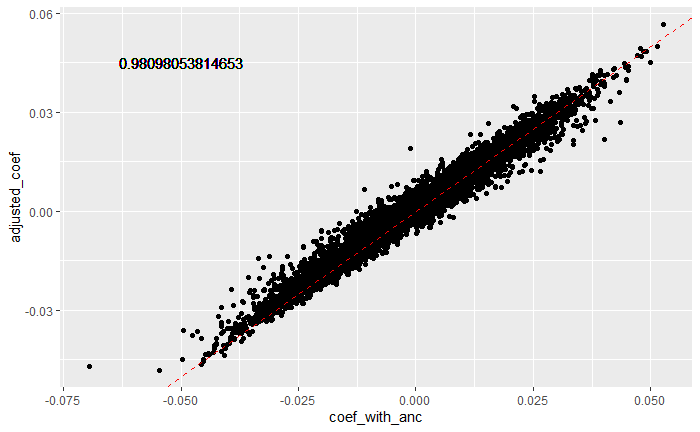

```r
ggplot(results, aes(x = coef_with_anc, y = adjusted_coef)) +
  geom_point() +
  geom_abline(slope = 1, intercept = 0, color = "red", linetype = "dashed") +
  geom_text(aes(x = -0.05, y = 0.045), label = CCC(results$coef_with_anc, results$adjusted_coef)$rho.c$est)
```

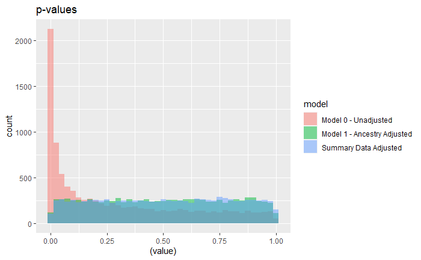

```r
results$adjusted_p <- pnorm(-abs(results$adjusted_z)) *2
results$SNP <- 1:1000
p_long <- results %>% pivot_longer(cols = c(p_no_anc, p_with_anc, adjusted_p))

p_long <- p_long %>% rowwise() %>%
  mutate(model = case_when(name == "adjusted_p" ~ "Summary Data Adjusted",
                           name == "p_no_anc" ~ "Model 0 - Unadjusted",
                           name == "p_with_anc" ~ "Model 1 - Ancestry Adjusted"))

ggplot(p_long, aes(x= (value), fill = model)) +
  geom_histogram(binwidth = 0.025, alpha = 0.5, position = "identity") +
  ggtitle("p-values")
```

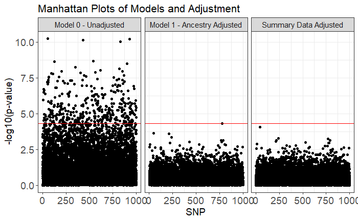

```r
ggplot(p_long, aes(x = SNP, y = -log10(value))) +
  geom_point() +
  ylab("-log10(p-value)") +
  ggtitle("Manhattan Plots of Models and Adjustment") +
  geom_hline(yintercept = -log10(.05/1000), color = "red") +
  theme_bw() +
  theme(plot.title = element_text(size = 16),
        axis.text = element_text(size = 14),
        axis.title = element_text(size = 14),
        strip.text = element_text(size = 11)) +
  facet_wrap(~model)
```

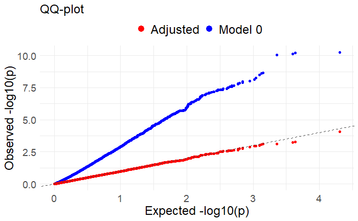

```r
qq0 <- as.data.frame(qqplot(-log10(results$p_with_anc), -log10(results$p_no_anc),
                            plot.it = FALSE))
qq1 <- as.data.frame(qqplot(-log10(results$p_with_anc), -log10(results$adjusted_p),
                            plot.it = FALSE))
qq0$Model <- "Model 0"
qq1$Model <- "Adjusted"

qqdata <- rbind(qq0, qq1)

# also want a 95% confidence band
# normal distribution is mean 0 var 1
# qqdata$lowci <- qqdata$x - (qnorm((1+.95)/2))*qqdata$x
# qqdata$upci <- qqdata$x + (qnorm((1+.95)/2))*qqdata$x

ggplot(qqdata, aes(x = x, y = y, color = Model)) +
  geom_point() +
  #geom_ribbon(aes(ymax = upci, ymin = lowci), fill = "grey30", alpha = .4) +
  scale_color_manual(values = c("red", "blue")) +
  ggtitle("QQ-plot") +
  xlab("Expected -log10(p)") +
  ylab("Observed -log10(p)") +
  theme_minimal() +
  geom_abline(intercept = 0, slope = 1, linetype = "dashed", color = "grey30") +
  theme(axis.title = element_text(size = 18),
        axis.text = element_text(size = 14),
        legend.text = element_text(size = 18),
        plot.title = element_text(size = 18),
        legend.title = element_blank(),
        legend.position = "top") +
  guides(color = guide_legend(override.aes = list(size = 4)))
```

```r
# ggplot(qqdata, aes(x = x, y = y, color = Model)) +
#   geom_point() +
#   qqplotr::stat_qq_band(mapping = aes(sample = x, group = Model)) +
#   scale_color_manual(values = c("red", "blue")) +
#   ggtitle("QQ-plot") +
#   xlab("Expected -log10(p)") +
#   ylab("Observed -log10(p)") +
#   theme_minimal() +
#   geom_abline(intercept = 0, slope = 1, linetype = "dashed", color = "grey30") +
#   theme(axis.title = element_text(size = 18),
#         axis.text = element_text(size = 14),
#         legend.text = element_text(size = 18),
#         plot.title = element_text(size = 18),
#         legend.title = element_blank(),
#         legend.position = "top") +
#   guides(color = guide_legend(override.aes = list(size = 4)))
# ggsave("QQ-AFRAM-like.png", width = 8, height = 6, units = "in")
```

```r
DescTools::CCC(alpha[1,], alpha[2,])$rho.c$est
```

[output not shown]

## What happens if you include a reference ancestry that’s not actually present in the ancestry proportions?

```r
set.seed(100)
# simulate reference AFs
NRef <- 500
NObs <- 5000

# set the ancestry group proportions
ancestryProps <- c(0.78, 0.2, .02)

# calculate each individual's ancestry proportions
X_ancestryProps <- data.frame(prop_afr = rnorm(n = NObs, mean = ancestryProps[1], sd = .4))
X_ancestryProps[which(X_ancestryProps$prop_afr > 1), ] <- 1
X_ancestryProps[which(X_ancestryProps$prop_afr < 0), ] <- 0
X_ancestryProps$prop_eur <- .99 - X_ancestryProps$prop_afr
X_ancestryProps[which(X_ancestryProps$prop_eur < 0), ]$prop_eur <- 0
X_ancestryProps$prop_iam <- .01
for(i in 1:nrow(X_ancestryProps)) {
  X_ancestryProps[i,] <- X_ancestryProps[i,]/sum(X_ancestryProps[i,])
}

summary(X_ancestryProps)
```

```
    prop_afr         prop_eur         prop_iam
 Min.   :0.0000   Min.   :0.0000   Min.   :0.009901
 1st Qu.:0.5092   1st Qu.:0.0000   1st Qu.:0.009901
 Median :0.7816   Median :0.2084   Median :0.010000
 Mean   :0.7087   Mean   :0.2813   Mean   :0.009971
 3rd Qu.:0.9901   3rd Qu.:0.4808   3rd Qu.:0.010000
 Max.   :0.9901   Max.   :0.9900   Max.   :0.010000
```

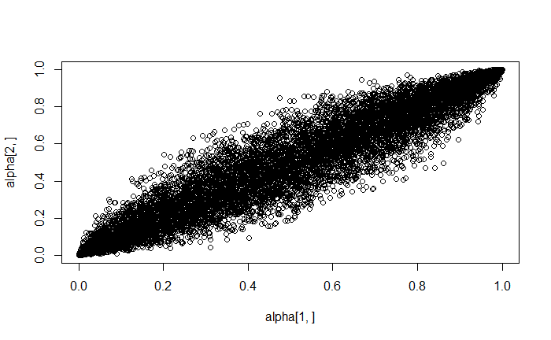

```r
# simulate reference AFs
NAnc <- 3
NSNPs <- nrow(chr19_sub)

rho = 0.95 # pairwise correlation between normal random variables used in copula
# rho is the average correlation between the group AFs
# I tested AFR - EUR which was ~.65, so I'll try that
# C N Yung used .95 - which would be more like finescale

# simulate AFs for each group
alpha = t(matrix(
  pnorm(
    MASS::mvrnorm(
      n = nrow(chr19_sub),
      mu = rep(0, NAnc),
      Sigma = rho * (rep(1, NAnc) %*% t(rep(1, NAnc))) + (1 - rho) * diag(NAnc)
    )
  ),
  ncol = NAnc
))

#Check correlation between alphas (reference AFs)
plot(alpha[1,], alpha[2,])
```

```r
DescTools::CCC(alpha[1,], alpha[2,])$rho.c$est
```

```
[1] 0.9453029
```

```r
# across-group ancestry-weighted means of those frequencies at each SNP
alpha_bar = colMeans(as.matrix(X_ancestryProps)) %*% alpha

# simulate genotypes where each row is an individual and each column is the AC for each SNP
# uses alpha (allele frequencies)
genos <- matrix(0, nrow = NObs, ncol = nrow(chr19_sub))
genos_std <- genos
for(j in 1:ncol(genos)) {
  raw_geno <- rbinom(NObs, size = 2, prob = as.matrix(X_ancestryProps) %*% alpha[,j])
  if(length(unique(raw_geno) == 1)) { # ensure all individuals don't have same genotype count
    # otherwise will end up with zero variance
    if(unique(raw_geno)[1] == 1) {
      raw_geno[1] <- 0
    } else {
      raw_geno[1] <- 1
    }
  }
  genos[,j] <- raw_geno
  genos_std[,j] <- (genos[,j]-mean(genos[,j])) / sd(genos[,j])
}



# simulate phenotypes, raw and centered
gamma = 0.05 # proportion of variance of phenotype explained by ancestry

W <- rnorm(NObs, mean = 0, sd = 1)
tau <- sqrt((gamma/(1-gamma))/(sum(as.matrix(X_ancestryProps)^2)/NObs))
mu <- rnorm(NAnc, mean = 0, sd = tau)

raw_phenotype <- as.matrix(X_ancestryProps) %*% mu + W

# center the phenotypes
centered_phenotype <- scale(raw_phenotype, scale = F)

# Now do the actual regressions
results <- data.frame(coef_no_anc = rep(0, NSNPs), # beta_0j
                      coef_with_anc = rep(0, NSNPs), #beta_1j
                      z_no_anc = rep(0, NSNPs),
                      z_with_anc = rep(0, NSNPs),
                      p_no_anc = rep(0, NSNPs),
                      p_with_anc = rep(0, NSNPs))


for(j in 1:nrow(chr19_sub)) {
  alldata <- data.frame(Y = centered_phenotype,
                      X_afr = X_ancestryProps$prop_afr,
                      X_eur = X_ancestryProps$prop_eur,
                      X_iam = X_ancestryProps$prop_iam,
                      Z = genos_std[,j])
  # first do model 0 without ancestry
  mod_no_anc <- lm(Y ~ 0 + ., data = alldata[ ,c(1, NAnc+2)])
  results[j,]$coef_no_anc <- summary(mod_no_anc)$coef[1]
  results[j,]$z_no_anc <- summary(mod_no_anc)$coef[3]
  results[j,]$p_no_anc <- summary(mod_no_anc)$coef[4]

  # now do model 1 with ancestry
  mod_with_anc <- lm(Y ~ 0 + ., data = alldata)
  results[j,]$coef_with_anc <- summary(mod_with_anc)$coef[(NAnc+1), 1]
  results[j,]$z_with_anc <- summary(mod_with_anc)$coef[(NAnc+1),3]
  results[j,]$p_with_anc <- summary(mod_with_anc)$coef[(NAnc+1),4]

  if(j %% 1000 == 0) {
    print(paste0("SNP ", j, " done"))
  }
}
```

```
[1] "SNP 1000 done"
[1] "SNP 2000 done"
[1] "SNP 3000 done"
[1] "SNP 4000 done"
[1] "SNP 5000 done"
[1] "SNP 6000 done"
[1] "SNP 7000 done"
[1] "SNP 8000 done"
[1] "SNP 9000 done"
[1] "SNP 10000 done"
```

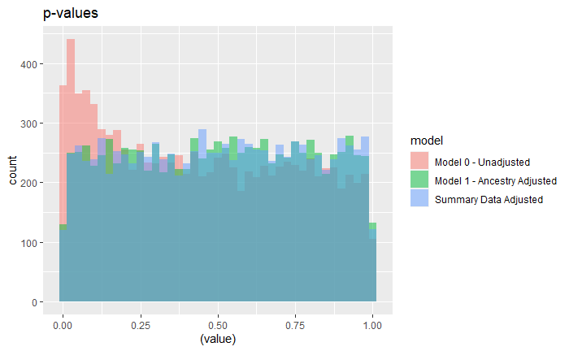

```r
# Regression of beta_0j and Z_0j on the omegas

# alpha_bar (assuming we average all alpha_kj because all groups are equally represented)
alpha_bar_dash <- colMeans(alpha)

omega1 <- alpha[1, ]/sqrt(alpha_bar_dash*(1-alpha_bar_dash))
omega2 <- alpha[2, ]/sqrt(alpha_bar_dash*(1-alpha_bar_dash))
omega3 <- alpha[3, ]/sqrt(alpha_bar_dash*(1-alpha_bar_dash))

# construct dataframe with beta0_hat, z0, omega_1 ... omega_NAnc
summary_data <- data.frame(beta0 = results$coef_no_anc,
                           z0 = results$z_no_anc,
                           omega1 = omega1,
                           omega2 = omega2,
                           omega3 = omega3)

# use regression of beta0 and z0 on omega_k's to back out of the adjusted coefficients and z-score respectively
coef_summary_mod <- lm(summary_data[ , c(1, 3:(NAnc+2))])
z_summary_mod <- lm(summary_data[ ,c(2:(NAnc+2))])
phi_hat <- coef_summary_mod$coef[2:(NAnc+1)]
theta_hat <- z_summary_mod$coef[2:(NAnc+1)]

# omega1phi1 <- summary_data$omega1 * phi_hat[1]
# omega2phi2 <- summary_data$omega2 * phi_hat[2]
# beta1 <- results$coef_no_anc - omega1phi1 - omega2phi2

adjusted_coef <- results$coef_no_anc - as.matrix(summary_data[ , 3:(NAnc+2)]) %*% phi_hat
adjusted_z <- results$z_no_anc - as.matrix(summary_data[ ,3:(NAnc+2)]) %*% theta_hat

results <- results %>%
  mutate(adjusted_coef = adjusted_coef,
         adjusted_z = adjusted_z)

results$adjusted_p <- pnorm(-abs(results$adjusted_z)) *2
results$SNP <- 1:1000
p_long <- results %>% pivot_longer(cols = c(p_no_anc, p_with_anc, adjusted_p))

p_long <- p_long %>% rowwise() %>%
  mutate(model = case_when(name == "adjusted_p" ~ "Summary Data Adjusted",
                           name == "p_no_anc" ~ "Model 0 - Unadjusted",
                           name == "p_with_anc" ~ "Model 1 - Ancestry Adjusted"))

ggplot(p_long, aes(x= (value), fill = model)) +
  geom_histogram(binwidth = 0.025, alpha = 0.5, position = "identity") +
  ggtitle("p-values")
```

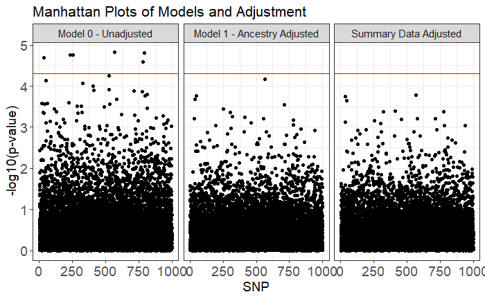

```r
ggplot(p_long, aes(x = SNP, y = -log10(value))) +
  geom_point() +
  ylab("-log10(p-value)") +
  ggtitle("Manhattan Plots of Models and Adjustment") +
  geom_hline(yintercept = -log10(.05/1000), color = "red") +
  theme_bw() +
  theme(plot.title = element_text(size = 16),
        axis.text = element_text(size = 14),
        axis.title = element_text(size = 14),
        strip.text = element_text(size = 11)) +
  facet_wrap(~model)
```

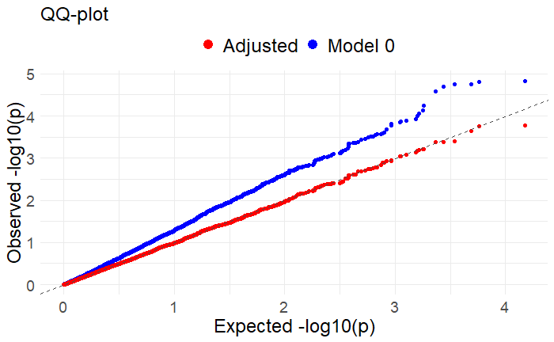

```r
qq0 <- as.data.frame(qqplot(-log10(results$p_with_anc), -log10(results$p_no_anc),
                            plot.it = FALSE))
qq1 <- as.data.frame(qqplot(-log10(results$p_with_anc), -log10(results$adjusted_p),
                            plot.it = FALSE))
qq0$Model <- "Model 0"
qq1$Model <- "Adjusted"

qqdata <- rbind(qq0, qq1)

# also want a 95% confidence band
# normal distribution is mean 0 var 1
# qqdata$lowci <- qqdata$x - (qnorm((1+.95)/2))*qqdata$x
# qqdata$upci <- qqdata$x + (qnorm((1+.95)/2))*qqdata$x

ggplot(qqdata, aes(x = x, y = y, color = Model)) +
  geom_point() +
  #geom_ribbon(aes(ymax = upci, ymin = lowci), fill = "grey30", alpha = .4) +
  scale_color_manual(values = c("red", "blue")) +
  ggtitle("QQ-plot") +
  xlab("Expected -log10(p)") +
  ylab("Observed -log10(p)") +
  theme_minimal() +
  geom_abline(intercept = 0, slope = 1, linetype = "dashed", color = "grey30") +
  theme(axis.title = element_text(size = 18),
        axis.text = element_text(size = 14),
        legend.text = element_text(size = 18),
        plot.title = element_text(size = 18),
        legend.title = element_blank(),
        legend.position = "top") +
  guides(color = guide_legend(override.aes = list(size = 4)))
```

So it still worked with a fine-scale ancestry included that wasn’t really present in the observed sample

## Next question: What if it’s missing a fine-scale reference but has high similarity to others included?

```r
set.seed(100)
# simulate reference AFs
NRef <- 500
NObs <- 5000

# set the ancestry group proportions
ancestryProps <- c(0.6, 0.2, .2)

# calculate each individual's ancestry proportions
X_ancestryProps <- data.frame(prop_afr = rnorm(n = NObs, mean = ancestryProps[1], sd = .4))
X_ancestryProps[which(X_ancestryProps$prop_afr > 1), ] <- 1
X_ancestryProps[which(X_ancestryProps$prop_afr < 0), ] <- 0
X_ancestryProps$prop_eur <- .8 - X_ancestryProps$prop_afr
X_ancestryProps[which(X_ancestryProps$prop_eur < 0), ]$prop_eur <- 0
X_ancestryProps$prop_iam <- .2
for(i in 1:nrow(X_ancestryProps)) {
  X_ancestryProps[i,] <- X_ancestryProps[i,]/sum(X_ancestryProps[i,])
}

summary(X_ancestryProps)
```

```
    prop_afr         prop_eur         prop_iam
 Min.   :0.0000   Min.   :0.0000   Min.   :0.1667
 1st Qu.:0.3292   1st Qu.:0.0000   1st Qu.:0.1869
 Median :0.6016   Median :0.1984   Median :0.2000
 Mean   :0.5412   Mean   :0.2666   Mean   :0.1922
 3rd Qu.:0.8131   3rd Qu.:0.4708   3rd Qu.:0.2000
 Max.   :0.8333   Max.   :0.8000   Max.   :0.2000
```

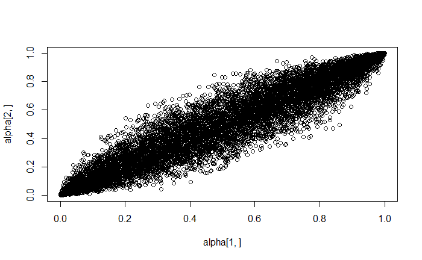

```r
# simulate reference AFs
NAnc <- 3
NSNPs <- nrow(chr19_sub)

rho = 0.95 # pairwise correlation between normal random variables used in copula
# rho is the average correlation between the group AFs
# I tested AFR - EUR which was ~.65, so I'll try that
# C N Yung used .95 - which would be more like finescale

# simulate AFs for each group
alpha = t(matrix(
  pnorm(
    MASS::mvrnorm(
      n = nrow(chr19_sub),
      mu = rep(0, NAnc),
      Sigma = rho * (rep(1, NAnc) %*% t(rep(1, NAnc))) + (1 - rho) * diag(NAnc)
    )
  ),
  ncol = NAnc
))

#Check correlation between alphas (reference AFs)
plot(alpha[1,], alpha[2,])
```

```r
DescTools::CCC(alpha[1,], alpha[2,])$rho.c$est
```

```
[1] 0.9453029
```

```r
# across-group ancestry-weighted means of those frequencies at each SNP
alpha_bar = colMeans(as.matrix(X_ancestryProps)) %*% alpha

# simulate genotypes where each row is an individual and each column is the AC for each SNP
# uses alpha (allele frequencies)
genos <- matrix(0, nrow = NObs, ncol = nrow(chr19_sub))
genos_std <- genos
for(j in 1:ncol(genos)) {
  raw_geno <- rbinom(NObs, size = 2, prob = as.matrix(X_ancestryProps) %*% alpha[,j])
  if(length(unique(raw_geno) == 1)) { # ensure all individuals don't have same genotype count
    # otherwise will end up with zero variance
    if(unique(raw_geno)[1] == 1) {
      raw_geno[1] <- 0
    } else {
      raw_geno[1] <- 1
    }
  }
  genos[,j] <- raw_geno
  genos_std[,j] <- (genos[,j]-mean(genos[,j])) / sd(genos[,j])
}



# simulate phenotypes, raw and centered
gamma = 0.05 # proportion of variance of phenotype explained by ancestry

W <- rnorm(NObs, mean = 0, sd = 1)
tau <- sqrt((gamma/(1-gamma))/(sum(as.matrix(X_ancestryProps)^2)/NObs))
mu <- rnorm(NAnc, mean = 0, sd = tau)

raw_phenotype <- as.matrix(X_ancestryProps) %*% mu + W

# center the phenotypes
centered_phenotype <- scale(raw_phenotype, scale = F)

# ------------------------------------------------------------------
# Now do the actual regressions
results <- data.frame(coef_no_anc = rep(0, NSNPs), # beta_0j
                      coef_with_anc = rep(0, NSNPs), #beta_1j
                      z_no_anc = rep(0, NSNPs),
                      z_with_anc = rep(0, NSNPs),
                      p_no_anc = rep(0, NSNPs),
                      p_with_anc = rep(0, NSNPs))


for(j in 1:nrow(chr19_sub)) {
  alldata <- data.frame(Y = centered_phenotype,
                      X_afr = X_ancestryProps$prop_afr,
                      X_eur = X_ancestryProps$prop_eur,
                      X_iam = X_ancestryProps$prop_iam,
                      Z = genos_std[,j])
  # first do model 0 without ancestry
  mod_no_anc <- lm(Y ~ 0 + ., data = alldata[ ,c(1, NAnc+2)])
  results[j,]$coef_no_anc <- summary(mod_no_anc)$coef[1]
  results[j,]$z_no_anc <- summary(mod_no_anc)$coef[3]
  results[j,]$p_no_anc <- summary(mod_no_anc)$coef[4]

  # now do model 1 with ancestry
  mod_with_anc <- lm(Y ~ 0 + ., data = alldata)
  results[j,]$coef_with_anc <- summary(mod_with_anc)$coef[(NAnc+1), 1]
  results[j,]$z_with_anc <- summary(mod_with_anc)$coef[(NAnc+1),3]
  results[j,]$p_with_anc <- summary(mod_with_anc)$coef[(NAnc+1),4]

  if(j %% 1000 == 0) {
    print(paste0("SNP ", j, " done"))
  }
}
```

```
[1] "SNP 1000 done"
[1] "SNP 2000 done"
[1] "SNP 3000 done"
[1] "SNP 4000 done"
[1] "SNP 5000 done"
[1] "SNP 6000 done"
[1] "SNP 7000 done"
[1] "SNP 8000 done"
[1] "SNP 9000 done"
[1] "SNP 10000 done"
```

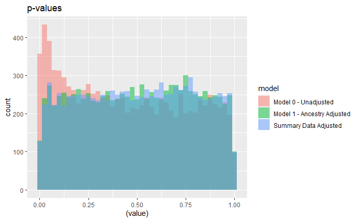

```r
# Regression of beta_0j and Z_0j on the omegas
# THIS IS WHERE THINGS CHANGE - REMOVE ONE OF THE REFERENCES
alpha <- alpha[1:2, ]
NAnc = 2

# alpha_bar (assuming we average all alpha_kj because all groups are equally represented)
alpha_bar_dash <- colMeans(alpha)

omega1 <- alpha[1, ]/sqrt(alpha_bar_dash*(1-alpha_bar_dash))
omega2 <- alpha[2, ]/sqrt(alpha_bar_dash*(1-alpha_bar_dash))
#omega3 <- alpha[3, ]/sqrt(alpha_bar_dash*(1-alpha_bar_dash))

# construct dataframe with beta0_hat, z0, omega_1 ... omega_NAnc
summary_data <- data.frame(beta0 = results$coef_no_anc,
                           z0 = results$z_no_anc,
                           omega1 = omega1,
                           omega2 = omega2)
                           #omega3 = omega3)

# use regression of beta0 and z0 on omega_k's to back out of the adjusted coefficients and z-score respectively
coef_summary_mod <- lm(summary_data[ , c(1, 3:(NAnc+2))])
z_summary_mod <- lm(summary_data[ ,c(2:(NAnc+2))])
phi_hat <- coef_summary_mod$coef[2:(NAnc+1)]
theta_hat <- z_summary_mod$coef[2:(NAnc+1)]

# omega1phi1 <- summary_data$omega1 * phi_hat[1]
# omega2phi2 <- summary_data$omega2 * phi_hat[2]
# beta1 <- results$coef_no_anc - omega1phi1 - omega2phi2

adjusted_coef <- results$coef_no_anc - as.matrix(summary_data[ , 3:(NAnc+2)]) %*% phi_hat
adjusted_z <- results$z_no_anc - as.matrix(summary_data[ ,3:(NAnc+2)]) %*% theta_hat

results <- results %>%
  mutate(adjusted_coef = adjusted_coef,
         adjusted_z = adjusted_z)

results$adjusted_p <- pnorm(-abs(results$adjusted_z)) *2
results$SNP <- 1:1000
p_long <- results %>% pivot_longer(cols = c(p_no_anc, p_with_anc, adjusted_p))

p_long <- p_long %>% rowwise() %>%
  mutate(model = case_when(name == "adjusted_p" ~ "Summary Data Adjusted",
                           name == "p_no_anc" ~ "Model 0 - Unadjusted",
                           name == "p_with_anc" ~ "Model 1 - Ancestry Adjusted"))

ggplot(p_long, aes(x= (value), fill = model)) +
  geom_histogram(binwidth = 0.025, alpha = 0.5, position = "identity") +
  ggtitle("p-values")
```

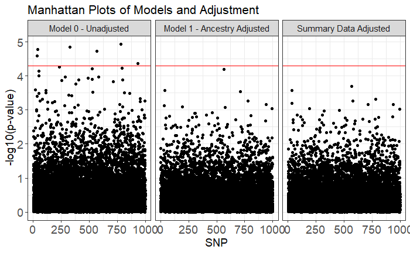

```r
ggplot(p_long, aes(x = SNP, y = -log10(value))) +
  geom_point() +
  ylab("-log10(p-value)") +
  ggtitle("Manhattan Plots of Models and Adjustment") +
  geom_hline(yintercept = -log10(.05/1000), color = "red") +
  theme_bw() +
  theme(plot.title = element_text(size = 16),
        axis.text = element_text(size = 14),
        axis.title = element_text(size = 14),
        strip.text = element_text(size = 11)) +
  facet_wrap(~model)
```

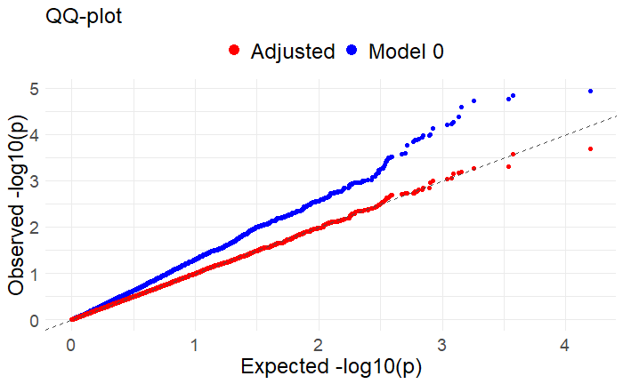

```r
qq0 <- as.data.frame(qqplot(-log10(results$p_with_anc), -log10(results$p_no_anc),
                            plot.it = FALSE))
qq1 <- as.data.frame(qqplot(-log10(results$p_with_anc), -log10(results$adjusted_p),
                            plot.it = FALSE))
qq0$Model <- "Model 0"
qq1$Model <- "Adjusted"

qqdata <- rbind(qq0, qq1)

# also want a 95% confidence band
# normal distribution is mean 0 var 1
# qqdata$lowci <- qqdata$x - (qnorm((1+.95)/2))*qqdata$x
# qqdata$upci <- qqdata$x + (qnorm((1+.95)/2))*qqdata$x

ggplot(qqdata, aes(x = x, y = y, color = Model)) +
  geom_point() +
  #geom_ribbon(aes(ymax = upci, ymin = lowci), fill = "grey30", alpha = .4) +
  scale_color_manual(values = c("red", "blue")) +
  ggtitle("QQ-plot") +
  xlab("Expected -log10(p)") +
  ylab("Observed -log10(p)") +
  theme_minimal() +
  geom_abline(intercept = 0, slope = 1, linetype = "dashed", color = "grey30") +
  theme(axis.title = element_text(size = 18),
        axis.text = element_text(size = 14),
        legend.text = element_text(size = 18),
        plot.title = element_text(size = 18),
        legend.title = element_blank(),
        legend.position = "top") +
  guides(color = guide_legend(override.aes = list(size = 4)))
```

Still looks good when there’s high similarity (fine-scale) and one is missing

## Next questions: What if we’re missing a continental reference?

```r
set.seed(100)
# simulate reference AFs
NRef <- 500
NObs <- 5000

# set the ancestry group proportions
ancestryProps <- c(0.6, 0.2, .2)

# calculate each individual's ancestry proportions
X_ancestryProps <- data.frame(prop_afr = rnorm(n = NObs, mean = ancestryProps[1], sd = .4))
X_ancestryProps[which(X_ancestryProps$prop_afr > 1), ] <- 1
X_ancestryProps[which(X_ancestryProps$prop_afr < 0), ] <- 0
X_ancestryProps$prop_eur <- .8 - X_ancestryProps$prop_afr
X_ancestryProps[which(X_ancestryProps$prop_eur < 0), ]$prop_eur <- 0
X_ancestryProps$prop_iam <- .2
for(i in 1:nrow(X_ancestryProps)) {
  X_ancestryProps[i,] <- X_ancestryProps[i,]/sum(X_ancestryProps[i,])
}

summary(X_ancestryProps)
```

```
    prop_afr         prop_eur         prop_iam
 Min.   :0.0000   Min.   :0.0000   Min.   :0.1667
 1st Qu.:0.3292   1st Qu.:0.0000   1st Qu.:0.1869
 Median :0.6016   Median :0.1984   Median :0.2000
 Mean   :0.5412   Mean   :0.2666   Mean   :0.1922
 3rd Qu.:0.8131   3rd Qu.:0.4708   3rd Qu.:0.2000
 Max.   :0.8333   Max.   :0.8000   Max.   :0.2000
```

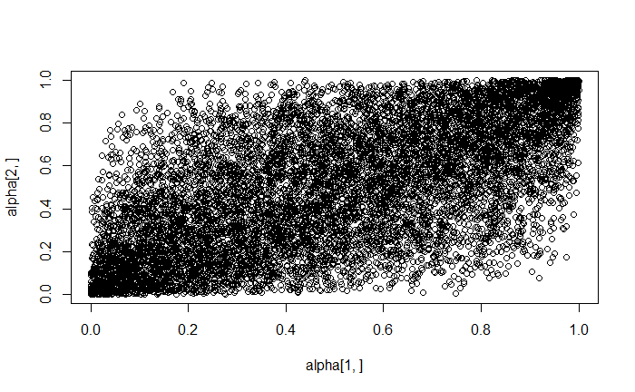

```r
# simulate reference AFs
NAnc <- 3
NSNPs <- nrow(chr19_sub)

rho = 0.65 # pairwise correlation between normal random variables used in copula
# rho is the average correlation between the group AFs
# I tested AFR - EUR which was ~.65, so I'll try that
# C N Yung used .95 - which would be more like finescale

# simulate AFs for each group
alpha = t(matrix(
  pnorm(
    MASS::mvrnorm(
      n = nrow(chr19_sub),
      mu = rep(0, NAnc),
      Sigma = rho * (rep(1, NAnc) %*% t(rep(1, NAnc))) + (1 - rho) * diag(NAnc)
    )
  ),
  ncol = NAnc
))

#Check correlation between alphas (reference AFs)
plot(alpha[1,], alpha[2,])
```

```r
DescTools::CCC(alpha[1,], alpha[2,])$rho.c$est
```

```
[1] 0.6274949
```

```r
# across-group ancestry-weighted means of those frequencies at each SNP
alpha_bar = colMeans(as.matrix(X_ancestryProps)) %*% alpha

# simulate genotypes where each row is an individual and each column is the AC for each SNP
# uses alpha (allele frequencies)
genos <- matrix(0, nrow = NObs, ncol = nrow(chr19_sub))
genos_std <- genos
for(j in 1:ncol(genos)) {
  raw_geno <- rbinom(NObs, size = 2, prob = as.matrix(X_ancestryProps) %*% alpha[,j])
  if(length(unique(raw_geno) == 1)) { # ensure all individuals don't have same genotype count
    # otherwise will end up with zero variance
    if(unique(raw_geno)[1] == 1) {
      raw_geno[1] <- 0
    } else {
      raw_geno[1] <- 1
    }
  }
  genos[,j] <- raw_geno
  genos_std[,j] <- (genos[,j]-mean(genos[,j])) / sd(genos[,j])
}



# simulate phenotypes, raw and centered
gamma = 0.05 # proportion of variance of phenotype explained by ancestry

W <- rnorm(NObs, mean = 0, sd = 1)
tau <- sqrt((gamma/(1-gamma))/(sum(as.matrix(X_ancestryProps)^2)/NObs))
mu <- rnorm(NAnc, mean = 0, sd = tau)

raw_phenotype <- as.matrix(X_ancestryProps) %*% mu + W

# center the phenotypes
centered_phenotype <- scale(raw_phenotype, scale = F)

# ------------------------------------------------------------------
# Now do the actual regressions
results <- data.frame(coef_no_anc = rep(0, NSNPs), # beta_0j
                      coef_with_anc = rep(0, NSNPs), #beta_1j
                      z_no_anc = rep(0, NSNPs),
                      z_with_anc = rep(0, NSNPs),
                      p_no_anc = rep(0, NSNPs),
                      p_with_anc = rep(0, NSNPs))


for(j in 1:nrow(chr19_sub)) {
  alldata <- data.frame(Y = centered_phenotype,
                      X_afr = X_ancestryProps$prop_afr,
                      X_eur = X_ancestryProps$prop_eur,
                      X_iam = X_ancestryProps$prop_iam,
                      Z = genos_std[,j])
  # first do model 0 without ancestry
  mod_no_anc <- lm(Y ~ 0 + ., data = alldata[ ,c(1, NAnc+2)])
  results[j,]$coef_no_anc <- summary(mod_no_anc)$coef[1]
  results[j,]$z_no_anc <- summary(mod_no_anc)$coef[3]
  results[j,]$p_no_anc <- summary(mod_no_anc)$coef[4]

  # now do model 1 with ancestry
  mod_with_anc <- lm(Y ~ 0 + ., data = alldata)
  results[j,]$coef_with_anc <- summary(mod_with_anc)$coef[(NAnc+1), 1]
  results[j,]$z_with_anc <- summary(mod_with_anc)$coef[(NAnc+1),3]
  results[j,]$p_with_anc <- summary(mod_with_anc)$coef[(NAnc+1),4]

  if(j %% 1000 == 0) {
    print(paste0("SNP ", j, " done"))
  }
}
```

```
[1] "SNP 1000 done"
[1] "SNP 2000 done"
[1] "SNP 3000 done"
[1] "SNP 4000 done"
[1] "SNP 5000 done"
[1] "SNP 6000 done"
[1] "SNP 7000 done"
[1] "SNP 8000 done"
[1] "SNP 9000 done"
[1] "SNP 10000 done"
```

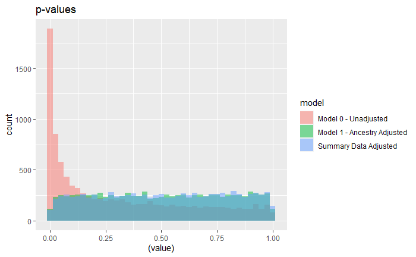

```r
# Regression of beta_0j and Z_0j on the omegas
# THIS IS WHERE THINGS CHANGE - REMOVE ONE OF THE REFERENCES
alpha <- alpha[1:2, ]
NAnc = 2

# alpha_bar (assuming we average all alpha_kj because all groups are equally represented)
alpha_bar_dash <- colMeans(alpha)

omega1 <- alpha[1, ]/sqrt(alpha_bar_dash*(1-alpha_bar_dash))
omega2 <- alpha[2, ]/sqrt(alpha_bar_dash*(1-alpha_bar_dash))
#omega3 <- alpha[3, ]/sqrt(alpha_bar_dash*(1-alpha_bar_dash))

# construct dataframe with beta0_hat, z0, omega_1 ... omega_NAnc
summary_data <- data.frame(beta0 = results$coef_no_anc,
                           z0 = results$z_no_anc,
                           omega1 = omega1,
                           omega2 = omega2)
                           #omega3 = omega3)

# use regression of beta0 and z0 on omega_k's to back out of the adjusted coefficients and z-score respectively
coef_summary_mod <- lm(summary_data[ , c(1, 3:(NAnc+2))])
z_summary_mod <- lm(summary_data[ ,c(2:(NAnc+2))])
phi_hat <- coef_summary_mod$coef[2:(NAnc+1)]
theta_hat <- z_summary_mod$coef[2:(NAnc+1)]

# omega1phi1 <- summary_data$omega1 * phi_hat[1]
# omega2phi2 <- summary_data$omega2 * phi_hat[2]
# beta1 <- results$coef_no_anc - omega1phi1 - omega2phi2

adjusted_coef <- results$coef_no_anc - as.matrix(summary_data[ , 3:(NAnc+2)]) %*% phi_hat
adjusted_z <- results$z_no_anc - as.matrix(summary_data[ ,3:(NAnc+2)]) %*% theta_hat

results <- results %>%
  mutate(adjusted_coef = adjusted_coef,
         adjusted_z = adjusted_z)

results$adjusted_p <- pnorm(-abs(results$adjusted_z)) *2
results$SNP <- 1:1000
p_long <- results %>% pivot_longer(cols = c(p_no_anc, p_with_anc, adjusted_p))

p_long <- p_long %>% rowwise() %>%
  mutate(model = case_when(name == "adjusted_p" ~ "Summary Data Adjusted",
                           name == "p_no_anc" ~ "Model 0 - Unadjusted",
                           name == "p_with_anc" ~ "Model 1 - Ancestry Adjusted"))

ggplot(p_long, aes(x= (value), fill = model)) +
  geom_histogram(binwidth = 0.025, alpha = 0.5, position = "identity") +
  ggtitle("p-values")
```

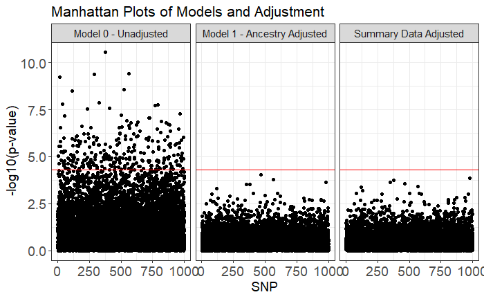

```r
ggplot(p_long, aes(x = SNP, y = -log10(value))) +
  geom_point() +
  ylab("-log10(p-value)") +
  ggtitle("Manhattan Plots of Models and Adjustment") +
  geom_hline(yintercept = -log10(.05/1000), color = "red") +
  theme_bw() +
  theme(plot.title = element_text(size = 16),
        axis.text = element_text(size = 14),
        axis.title = element_text(size = 14),
        strip.text = element_text(size = 11)) +
  facet_wrap(~model)
```

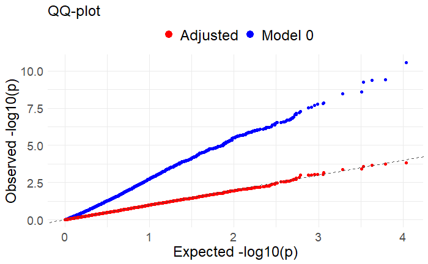

```r
qq0 <- as.data.frame(qqplot(-log10(results$p_with_anc), -log10(results$p_no_anc),
                            plot.it = FALSE))
qq1 <- as.data.frame(qqplot(-log10(results$p_with_anc), -log10(results$adjusted_p),
                            plot.it = FALSE))
qq0$Model <- "Model 0"
qq1$Model <- "Adjusted"

qqdata <- rbind(qq0, qq1)

# also want a 95% confidence band
# normal distribution is mean 0 var 1
# qqdata$lowci <- qqdata$x - (qnorm((1+.95)/2))*qqdata$x
# qqdata$upci <- qqdata$x + (qnorm((1+.95)/2))*qqdata$x

ggplot(qqdata, aes(x = x, y = y, color = Model)) +
  geom_point() +
  #geom_ribbon(aes(ymax = upci, ymin = lowci), fill = "grey30", alpha = .4) +
  scale_color_manual(values = c("red", "blue")) +
  ggtitle("QQ-plot") +
  xlab("Expected -log10(p)") +
  ylab("Observed -log10(p)") +
  theme_minimal() +
  geom_abline(intercept = 0, slope = 1, linetype = "dashed", color = "grey30") +
  theme(axis.title = element_text(size = 18),
        axis.text = element_text(size = 14),
        legend.text = element_text(size = 18),
        plot.title = element_text(size = 18),
        legend.title = element_blank(),
        legend.position = "top") +
  guides(color = guide_legend(override.aes = list(size = 4)))
```

It still worked, even missing one of the references

What if it was missing the largest reference ancestry (AFR)

```r
set.seed(100)
# simulate reference AFs
NRef <- 500
NObs <- 5000

# set the ancestry group proportions
ancestryProps <- c(0.6, 0.2, .2)

# calculate each individual's ancestry proportions
X_ancestryProps <- data.frame(prop_afr = rnorm(n = NObs, mean = ancestryProps[1], sd = .4))
X_ancestryProps[which(X_ancestryProps$prop_afr > 1), ] <- 1
X_ancestryProps[which(X_ancestryProps$prop_afr < 0), ] <- 0
X_ancestryProps$prop_eur <- .8 - X_ancestryProps$prop_afr
X_ancestryProps[which(X_ancestryProps$prop_eur < 0), ]$prop_eur <- 0
X_ancestryProps$prop_iam <- .2
for(i in 1:nrow(X_ancestryProps)) {
  X_ancestryProps[i,] <- X_ancestryProps[i,]/sum(X_ancestryProps[i,])
}

summary(X_ancestryProps)
```

```
    prop_afr         prop_eur         prop_iam
 Min.   :0.0000   Min.   :0.0000   Min.   :0.1667
 1st Qu.:0.3292   1st Qu.:0.0000   1st Qu.:0.1869
 Median :0.6016   Median :0.1984   Median :0.2000
 Mean   :0.5412   Mean   :0.2666   Mean   :0.1922
 3rd Qu.:0.8131   3rd Qu.:0.4708   3rd Qu.:0.2000
 Max.   :0.8333   Max.   :0.8000   Max.   :0.2000
```

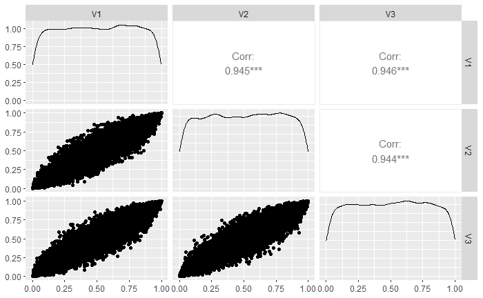

```r
# simulate reference AFs
NAnc <- 3
NSNPs <- nrow(chr19_sub)

rho = 0.95 # pairwise correlation between normal random variables used in copula
# rho is the average correlation between the group AFs
# I tested AFR - EUR which was ~.65, so I'll try that
# C N Yung used .95 - which would be more like finescale

# simulate AFs for each group
alpha = t(matrix(
  pnorm(
    MASS::mvrnorm(
      n = nrow(chr19_sub),
      mu = rep(0, NAnc),
      Sigma = rho * (rep(1, NAnc) %*% t(rep(1, NAnc))) + (1 - rho) * diag(NAnc)
    )
  ),
  ncol = NAnc
))

#Check correlation between alphas (reference AFs)
GGally::ggpairs(as.data.frame(t(alpha)))
```

```r
#DescTools::CCC(alpha[1,], alpha[2,])$rho.c$est

# across-group ancestry-weighted means of those frequencies at each SNP
alpha_bar = colMeans(as.matrix(X_ancestryProps)) %*% alpha

# simulate genotypes where each row is an individual and each column is the AC for each SNP
# uses alpha (allele frequencies)
genos <- matrix(0, nrow = NObs, ncol = nrow(chr19_sub))
genos_std <- genos
for(j in 1:ncol(genos)) {
  raw_geno <- rbinom(NObs, size = 2, prob = as.matrix(X_ancestryProps) %*% alpha[,j])
  if(length(unique(raw_geno) == 1)) { # ensure all individuals don't have same genotype count
    # otherwise will end up with zero variance
    if(unique(raw_geno)[1] == 1) {
      raw_geno[1] <- 0
    } else {
      raw_geno[1] <- 1
    }
  }
  genos[,j] <- raw_geno
  genos_std[,j] <- (genos[,j]-mean(genos[,j])) / sd(genos[,j])
}



# simulate phenotypes, raw and centered
gamma = 0.05 # proportion of variance of phenotype explained by ancestry

W <- rnorm(NObs, mean = 0, sd = 1)
tau <- sqrt((gamma/(1-gamma))/(sum(as.matrix(X_ancestryProps)^2)/NObs))
mu <- rnorm(NAnc, mean = 0, sd = tau)

raw_phenotype <- as.matrix(X_ancestryProps) %*% mu + W

# center the phenotypes
centered_phenotype <- scale(raw_phenotype, scale = F)

# ------------------------------------------------------------------
# Now do the actual regressions
results <- data.frame(coef_no_anc = rep(0, NSNPs), # beta_0j
                      coef_with_anc = rep(0, NSNPs), #beta_1j
                      z_no_anc = rep(0, NSNPs),
                      z_with_anc = rep(0, NSNPs),
                      p_no_anc = rep(0, NSNPs),
                      p_with_anc = rep(0, NSNPs))


for(j in 1:nrow(chr19_sub)) {
  alldata <- data.frame(Y = centered_phenotype,
                      X_afr = X_ancestryProps$prop_afr,
                      X_eur = X_ancestryProps$prop_eur,
                      X_iam = X_ancestryProps$prop_iam,
                      Z = genos_std[,j])
  # first do model 0 without ancestry
  mod_no_anc <- lm(Y ~ 0 + ., data = alldata[ ,c(1, NAnc+2)])
  results[j,]$coef_no_anc <- summary(mod_no_anc)$coef[1]
  results[j,]$z_no_anc <- summary(mod_no_anc)$coef[3]
  results[j,]$p_no_anc <- summary(mod_no_anc)$coef[4]

  # now do model 1 with ancestry
  mod_with_anc <- lm(Y ~ 0 + ., data = alldata)
  results[j,]$coef_with_anc <- summary(mod_with_anc)$coef[(NAnc+1), 1]
  results[j,]$z_with_anc <- summary(mod_with_anc)$coef[(NAnc+1),3]
  results[j,]$p_with_anc <- summary(mod_with_anc)$coef[(NAnc+1),4]

  if(j %% 1000 == 0) {
    print(paste0("SNP ", j, " done"))
  }
}
```

```
[1] "SNP 1000 done"
[1] "SNP 2000 done"
[1] "SNP 3000 done"
[1] "SNP 4000 done"
[1] "SNP 5000 done"
[1] "SNP 6000 done"
[1] "SNP 7000 done"
[1] "SNP 8000 done"
[1] "SNP 9000 done"
[1] "SNP 10000 done"
```

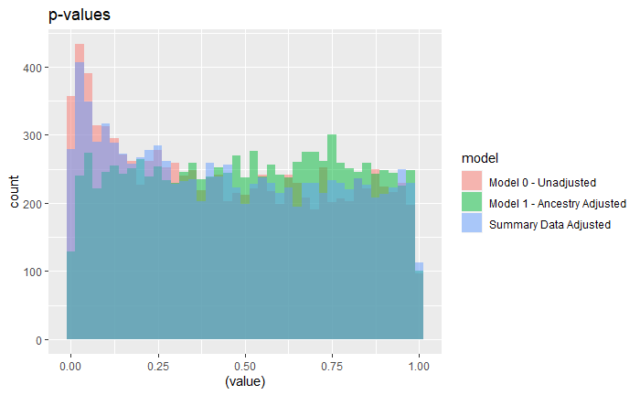

```r
# Regression of beta_0j and Z_0j on the omegas
# THIS IS WHERE THINGS CHANGE - REMOVE ONE OF THE REFERENCES
alpha <- alpha[2:3, ]
NAnc = 2

# alpha_bar (assuming we average all alpha_kj because all groups are equally represented)
alpha_bar_dash <- colMeans(alpha)

omega1 <- alpha[1, ]/sqrt(alpha_bar_dash*(1-alpha_bar_dash))
omega2 <- alpha[2, ]/sqrt(alpha_bar_dash*(1-alpha_bar_dash))
#omega3 <- alpha[3, ]/sqrt(alpha_bar_dash*(1-alpha_bar_dash))

# construct dataframe with beta0_hat, z0, omega_1 ... omega_NAnc
summary_data <- data.frame(beta0 = results$coef_no_anc,
                           z0 = results$z_no_anc,
                           omega1 = omega1,
                           omega2 = omega2)
                           #omega3 = omega3)

# use regression of beta0 and z0 on omega_k's to back out of the adjusted coefficients and z-score respectively
coef_summary_mod <- lm(summary_data[ , c(1, 3:(NAnc+2))])
z_summary_mod <- lm(summary_data[ ,c(2:(NAnc+2))])
phi_hat <- coef_summary_mod$coef[2:(NAnc+1)]
theta_hat <- z_summary_mod$coef[2:(NAnc+1)]

# omega1phi1 <- summary_data$omega1 * phi_hat[1]
# omega2phi2 <- summary_data$omega2 * phi_hat[2]
# beta1 <- results$coef_no_anc - omega1phi1 - omega2phi2

adjusted_coef <- results$coef_no_anc - as.matrix(summary_data[ , 3:(NAnc+2)]) %*% phi_hat
adjusted_z <- results$z_no_anc - as.matrix(summary_data[ ,3:(NAnc+2)]) %*% theta_hat

results <- results %>%
  mutate(adjusted_coef = adjusted_coef,
         adjusted_z = adjusted_z)

results$adjusted_p <- pnorm(-abs(results$adjusted_z)) *2
results$SNP <- 1:1000
p_long <- results %>% pivot_longer(cols = c(p_no_anc, p_with_anc, adjusted_p))

p_long <- p_long %>% rowwise() %>%
  mutate(model = case_when(name == "adjusted_p" ~ "Summary Data Adjusted",
                           name == "p_no_anc" ~ "Model 0 - Unadjusted",
                           name == "p_with_anc" ~ "Model 1 - Ancestry Adjusted"))

ggplot(p_long, aes(x= (value), fill = model)) +
  geom_histogram(binwidth = 0.025, alpha = 0.5, position = "identity") +
  ggtitle("p-values")
```

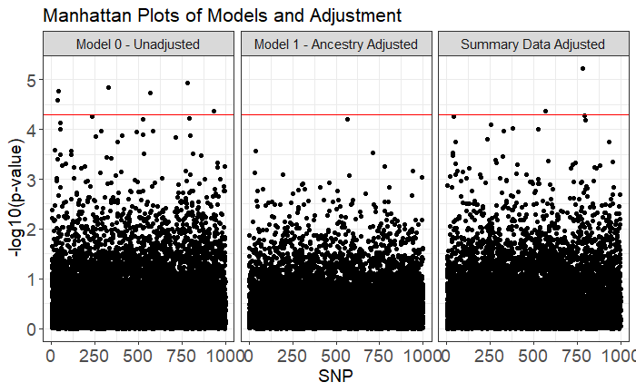

```r
ggplot(p_long, aes(x = SNP, y = -log10(value))) +
  geom_point() +
  ylab("-log10(p-value)") +
  ggtitle("Manhattan Plots of Models and Adjustment") +
  geom_hline(yintercept = -log10(.05/1000), color = "red") +
  theme_bw() +
  theme(plot.title = element_text(size = 16),
        axis.text = element_text(size = 14),
        axis.title = element_text(size = 14),
        strip.text = element_text(size = 11)) +
  facet_wrap(~model)
```

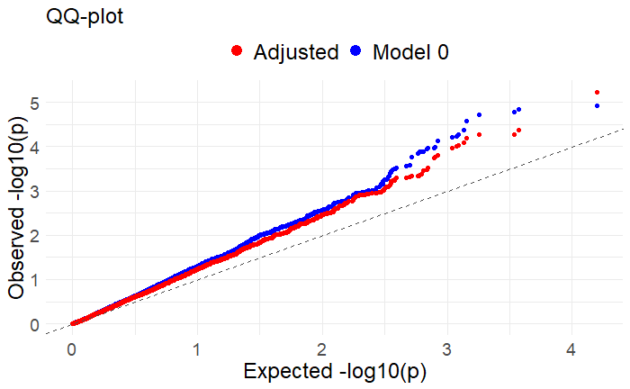

```r
qq0 <- as.data.frame(qqplot(-log10(results$p_with_anc), -log10(results$p_no_anc),
                            plot.it = FALSE))
qq1 <- as.data.frame(qqplot(-log10(results$p_with_anc), -log10(results$adjusted_p),
                            plot.it = FALSE))
qq0$Model <- "Model 0"
qq1$Model <- "Adjusted"

qqdata <- rbind(qq0, qq1)

# also want a 95% confidence band
# normal distribution is mean 0 var 1
# qqdata$lowci <- qqdata$x - (qnorm((1+.95)/2))*qqdata$x
# qqdata$upci <- qqdata$x + (qnorm((1+.95)/2))*qqdata$x

ggplot(qqdata, aes(x = x, y = y, color = Model)) +
  geom_point() +
  #geom_ribbon(aes(ymax = upci, ymin = lowci), fill = "grey30", alpha = .4) +
  scale_color_manual(values = c("red", "blue")) +
  ggtitle("QQ-plot") +
  xlab("Expected -log10(p)") +
  ylab("Observed -log10(p)") +
  theme_minimal() +
  geom_abline(intercept = 0, slope = 1, linetype = "dashed", color = "grey30") +
  theme(axis.title = element_text(size = 18),
        axis.text = element_text(size = 14),
        legend.text = element_text(size = 18),
        plot.title = element_text(size = 18),
        legend.title = element_blank(),
        legend.position = "top") +
  guides(color = guide_legend(override.aes = list(size = 4)))
```

Definitely doesn’t work as well as 60% is missing - not surprising